# Simulating clinical trials

Steve Simon

March 22, 2017

# Simulation before, during, and after a clinical trial: A Bayesian approach

## Abstract

Simulation of a clinical trial gives you answers to important economic, logistical, or scientific questions about the trial when some of the features are difficult to characterize with perfect precision. A Bayesian approach with informative priors offers a flexible framework for trial simulation. It provides a seamless transition from simulation prior to the trial to simulation during the trial itself. Although informative priors are controversial, you can avoid perceptions of bias by restricting the informative priors to clinical trial features that are independent of your research hypothesis. You can protect your interim predictions against unrealistic prior beliefs by implementing the hedging hyperprior, a simple hyperdistribution that downweights the strength of the prior when there is a discrepancy between the prior distribution and data observed during the trial itself. The Bayesian approach also gives you a simple post mortem analysis after the trial ends. You can compute percentile values by plugging the point estimates from the actual clinical trial data into the corresponding prior distributions. Over multiple trials, a deviation in these percentiles from a uniform distribution indicates biased specification of the informative priors. The Bayesian approach to trial simulation will be illustrated using various patient accrual models.

## Keywords

hedging hyperprior; informative prior distributions; Markov Chain Monte Carlo; patient accrual.

## Introduction

Consider a clinical trial that plans to run for 3 years (1,095 days). You hope to recruit 350 patients in that time, which would mean 0.32 patients per day or 9.6 patients per month. You suspect, however, that the accrual rate might actually be quite a bit higher or quite a bit lower than this target.

## Boxplot of prior distribution

Try setting a distribution on the monthly accrual rate that is gamma(70, 7.3). There’s a farily simple justification behind this choice, but for now let’s not worry about how we choose this particular distribution, except that it represents a prior strength of 0.2 relative to the target sample size.

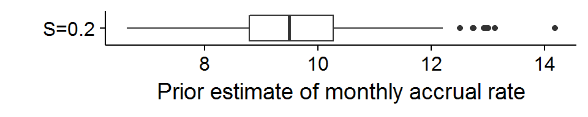

That seems a bit too wide, so try a distribution that is gamma(175, 18.25). This represents a prior strength of 0.5 relative to the target sample size.

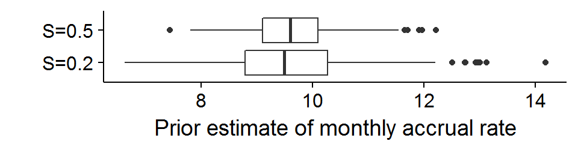

The second distribution (S=0.5) seems to match your gut feeling about accrual because a monthly accrual rate is unlikely to be smaller than 7.5 patients per month or more than 12.5 patients per month.

## Simulating various features of a trial

Now you are ready to simulate your clinical trial. You can simulate the amount of time that the trial takes to recruit 350 patients.

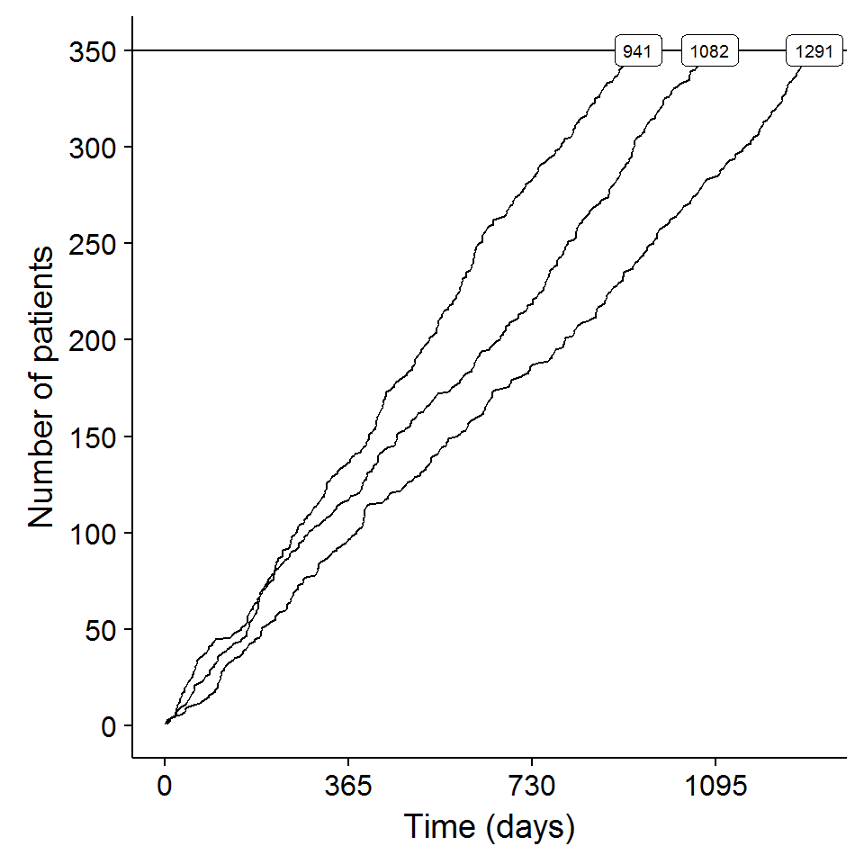

or the number of patients that you will get in 3 years.

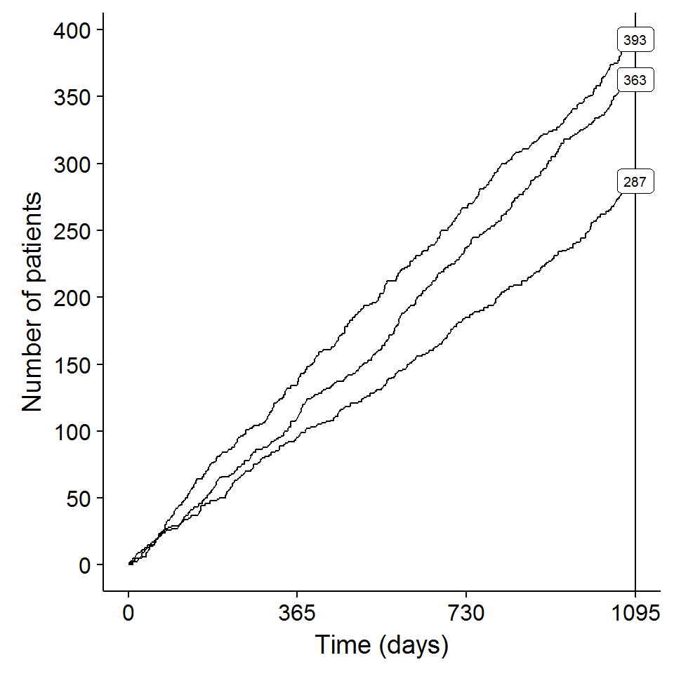

Or a trial that ends when you reach 350 patients or 3 years, whichever comes first.

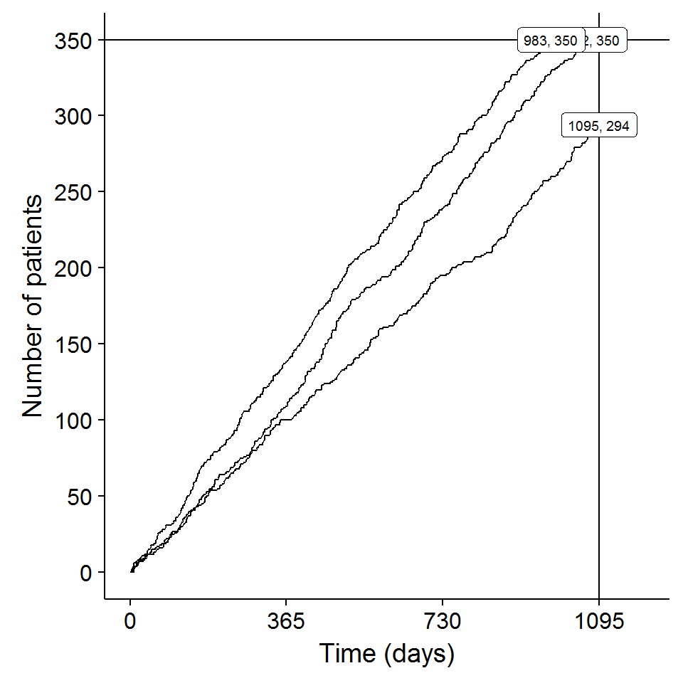

You could compute some composite measure like the total cost of the trial where each day that the trial is running costs 200 British Pounds and each patient recruited costs 800 British Pounds.

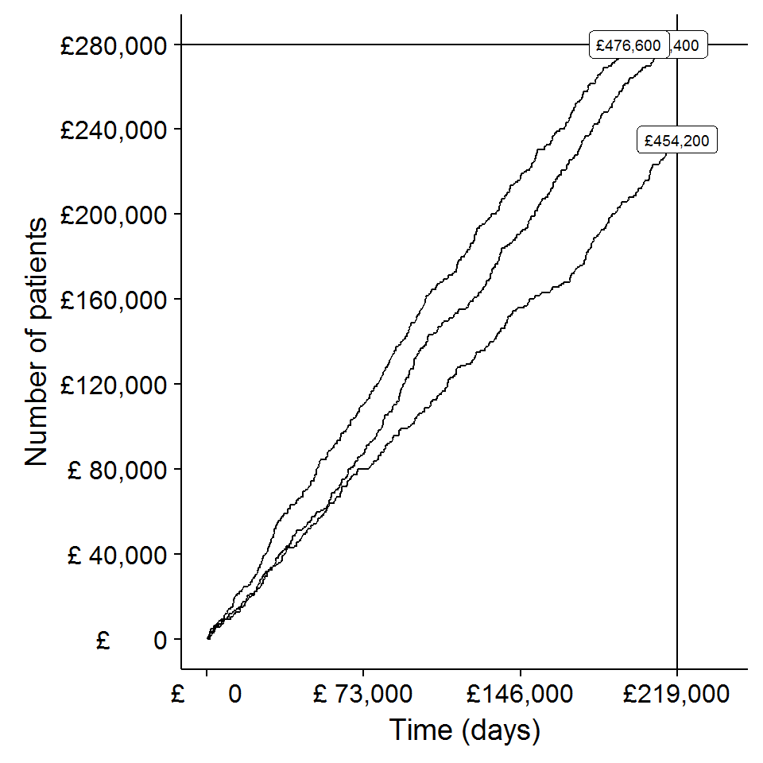

## Paths in a simulation

You won’t do this three times. You’ll do it several thousand times, because computer cycles are cheap. Here’s what a few thousand simulations might look like.

[figure not shown]

I also want to talk about simulating a clinical trial during the trial. What this means is that you have information sample size up to a certain point in time and you want to simulate how rapidly the sample size might increase for the remainder of time in the trial.

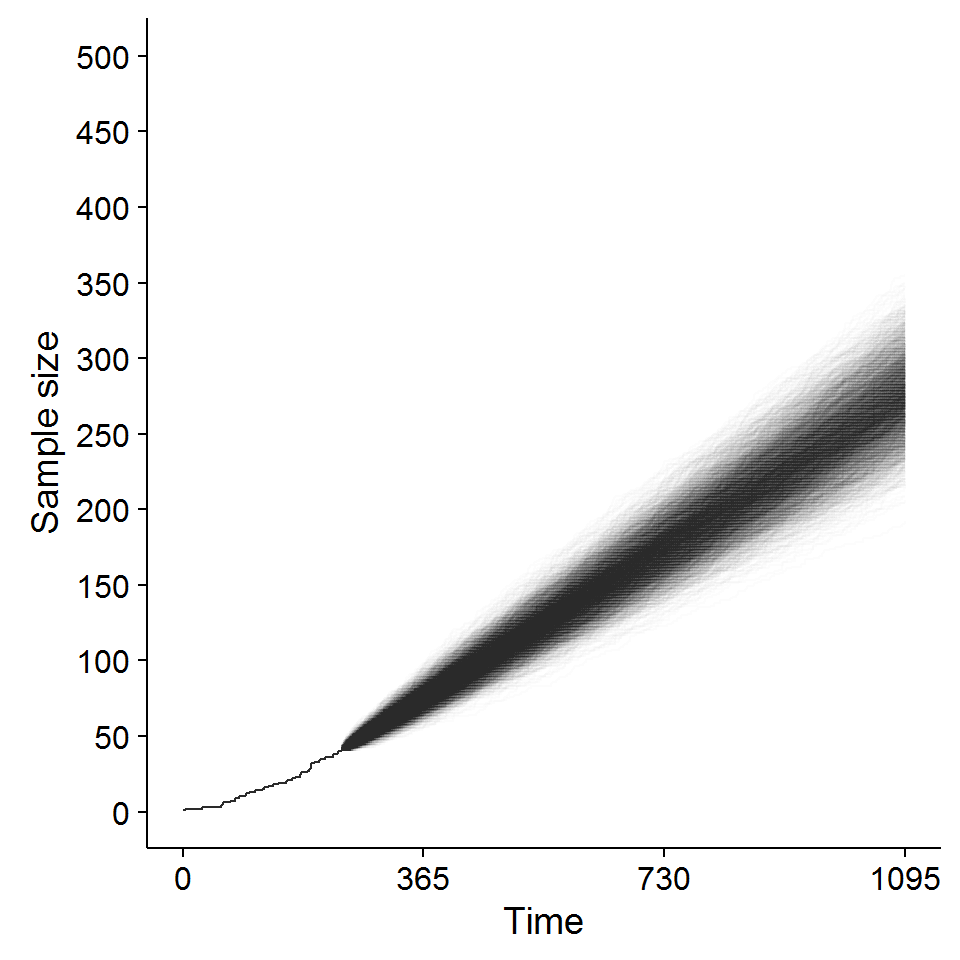

## Gamma Poisson models

From this point onward, we’ll summarize the simulations using means and standard errors and boxplots, but it’s worth remembering that what we are actually simulating is random paths.

Let’s also focus on simulations of the total sample size. In a Bayesian perspective, this is a Gamma Poisson model. The Poisson distribution models patient counts and a Gamma distribution restricts the rate parameter of the Poisson to a reasonable range.

Here is code in Stan (running inside of R) that simulates the results of a clinical trial with a target goal of 350 patients in 3 years (1095 days) and places a range of uncertainty on the accrual rate that is characterized by a gamma(175, 547.5). This is a prior distribution with a strength roughly equal to half the target sample size.

```
## data {
##   int<lower=1>           N; // planned number of patients
##   real<lower=0>          T; // planned duration of trial
##   real<lower=0, upper=1> S; // strength of prior
##   int<lower=0>           n; // observed patients
##   real<lower=0>          t; // observed time
## }
## parameters {
##   real<lower=0> lambda;
## }
## model {
##   lambda ~ gamma(N*S, T*S);
##   if (t>0) n ~ poisson(t*lambda);
## }
## generated quantities {
##   real<lower=0> Nstar;
##   Nstar = n + poisson_rng((T-t)*lambda);
## }
```

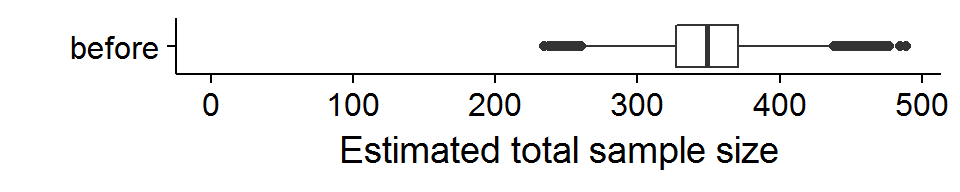

You can learn a lot by looking at how the estimated total sample size relates to the prior paramter(s).

Recall that in this simulation, you randomly select an accrual rate, gamma, and then you simulate a path based on that value of lambda. Not too surprisingly, the sample size depends on what lambda is chosen, though there is some variation, even for the same value of lambda.

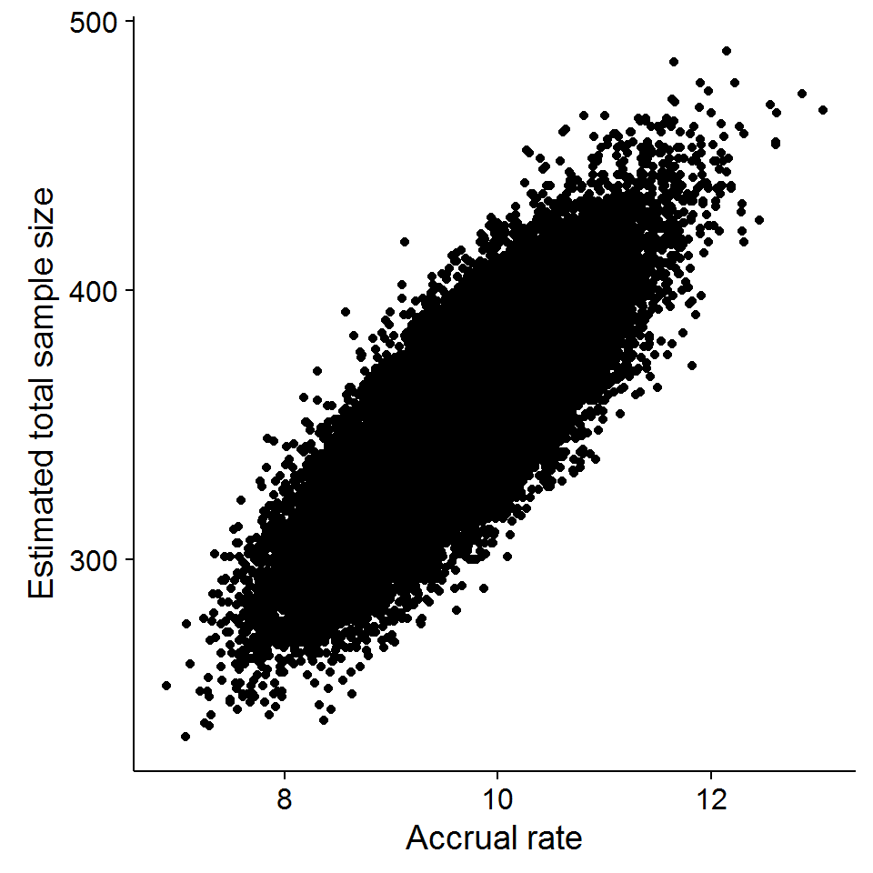

With a plot like this, you can run some sensitivity checks, such as “what would happen if the accrual rate were closer to 8.5 patients per month”

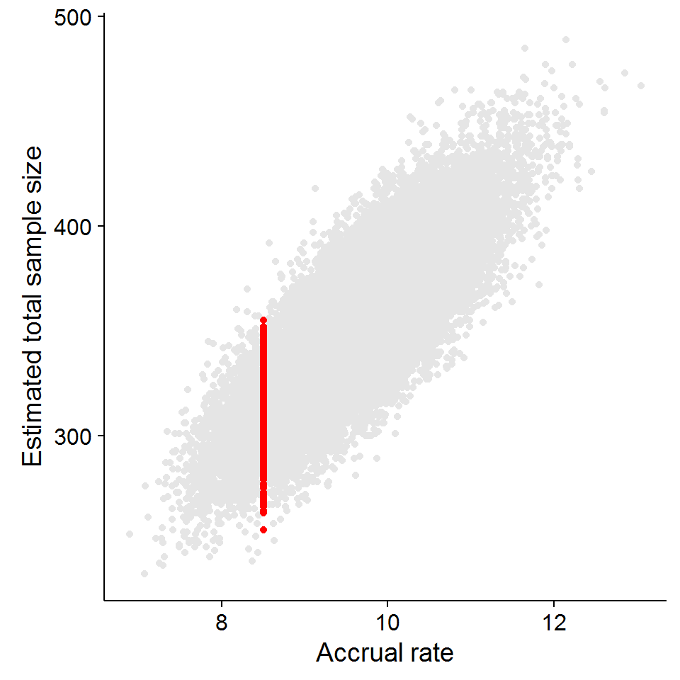

The key reason that you should run your simulations in Stan is that you can make a seamless transition to a simulation of a clinical trial during the trial itself. In this trial, the early accrual rate was much lower than expected. After 239 days, you have only gotten 41 patients. If you were on target, you would have 239/1095*350 = 76 patients by now. HOw much is this shortfall hurting us?

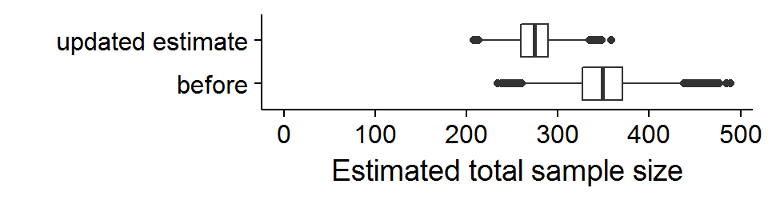

For this trial, you were able to get 341 patients, but it took a lot longer than you expected, 1336 days instead of 1095 days. Time to get ready for your next clinical trial. NOT SO FAST! You are not done with simulations when the trial is over. After the trial, take a look at how your accrual rate ranks relative to the range of accrual rates associated with your prior distribution.

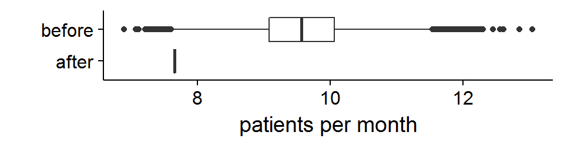

Okay, so you were way off. No one is going to hang you. If the same thing occurs over and over again, though, let’s talk.

## Early predictions

The commonly cited objection to informative priors is that they can bias the research. Whether that is true or not in a hypothesis testing framework is a matter of open debate. But using informative priors for operational characteristics of a study will not bias any resulting hypothesis tests.

While most Bayesian models use flat, non-informative, or only weakly informative prior distributions, when you are simulating the operational features of a clinical trial, you need to be bold and use strong informative prior distributions. There are three reasons for this.

First, if the best you can do for accrual rates for a clinical trial is a flat prior, what you are really saying is that you think you might see a couple of patients every day, or maybe a couple of patients every year, and you really don’t have a strong belief of one of these accrual rates over another. Anyone who can only predict accrual rates across such a wide range is unqualified to run a clinical trial.

Second, if you run a simulation with a flat prior you get results with an unrealisticly wide range.

Third, a strong prior distribution provides you with stable estimates early in the clinical trial. This is worth an illustration.

[figure not shown]

[figure not shown]

## Hedging priors

One problem with informative prior distributions is that many researchers get them wrong. They are either too optimistic about the accrual rate, or they think they know the accrual rate with more certainty than they actually do, or sometimes both.

You can minimize the problems associated with a bad informative prior by adding a hedging hyperparameter.

```
## data {
##   int<lower=1>           N; // planned number of patients
##   real<lower=0>          T; // planned duration of trial
##   real<lower=0, upper=1> S; // strength of prior
##   int<lower=0>           n; // observed patients
##   real<lower=0>          t; // observed time
## }
## parameters {
##   real<lower=0> lambda;
##   real<lower=1/(N*S), upper=2> pi; // hedging hyperprior
## }
## model {
##   pi ~ uniform(0, 2);
##   lambda ~ gamma(1+pi*(N*S-1), T/N+pi*(T*S-T/N));
##   if (t>0) n ~ poisson(t*lambda);
## }
## generated quantities {
##   real<lower=0> Nstar;
##   Nstar = n + poisson_rng((T-t)*lambda);
## }
```

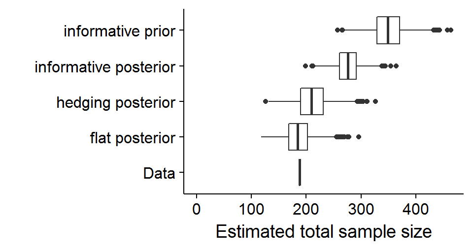

The following boxplot shows how much the hedging hyperparameter downweighted the prior distribution

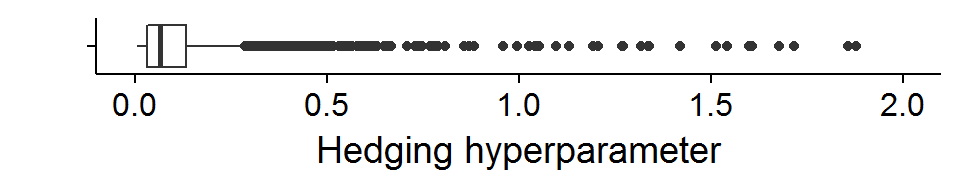

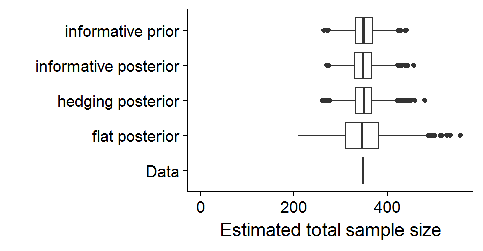

The following boxplot shows how much the hedging hyperparameter downweighted the prior distribution. In this case, the data actually upweighted the prior slightly on average. Think of it as a reward for choosing your prior distribution so well.

There’s a technical fix that you can make so that the mean of the hyperparameter never exceeds 1, but we won’t talk about it here.

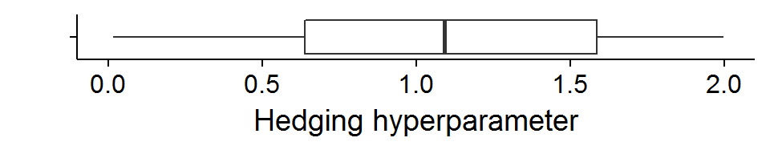

## Formulas for accrual delays

There are several different models for accrual delays. They may or may not include a start-up time before ANY accrual, and they may or may not include a warm-up time early in the trial when accrual is slower. If there is a warm-up time, there are several ways to model the transition from slow accrual to full accrual.

Here’s a linear transition from slow to full accrual. It has two parameters, the duration of the waiting to start period and the duration of the transition to full accrual.

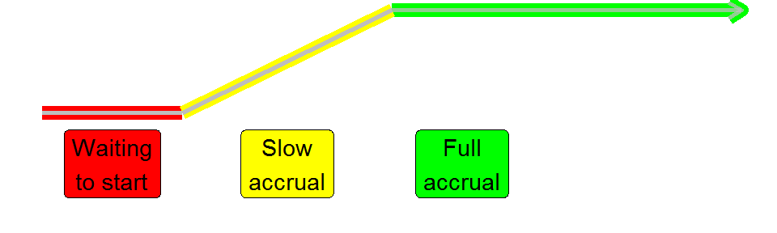

Here’s a discontinuous transition from slow to full accrual. It has three parameters, the duration of the waiting to start period, the rate during slow accrual, and the duration of the transition to full accrual.

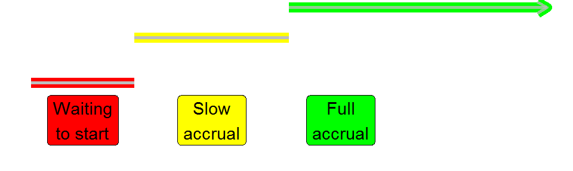

Here’s a partially discontinuous transition from slow to full accrual. It has the same three parameters as the earlier example, but the implementation is slightly different.

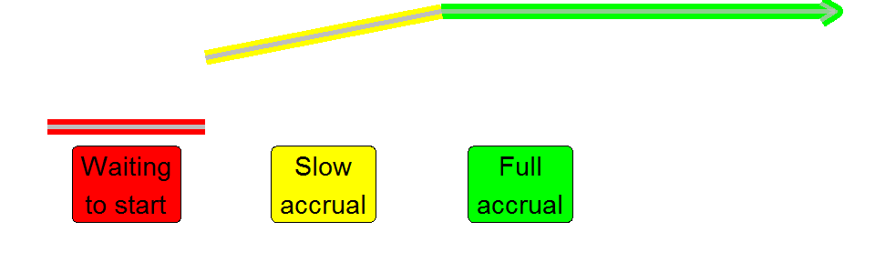

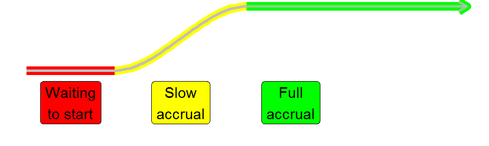

## Priors for a delay model

We’ll fit the discontinuous model, the second one shown, because it is convenient, but there are probably very few practical differences among these models. The discontinuous model has three parameters. Delta1 represents the duration of time waiting for the trial to start as a fraction of the total time planned. Delta2 represents the ratio of the accrual rate during the slow accrual period and the accrual rate during the full accrual period. Delta3 represents the duration of time for the slow accrual period as a fraction of the total time planned.

Generally, you should use strong priors here to limit delta1 and delta3 to the lower end of the range from 0 to 1. If you really thought that delta1 and/or delta3 would be much closer to 1, then you should rethink what your total time planned should be.

Here’s some possible prior distributions. For delta1, the proportion of the total planned time that you spend waiting for the study to get started, a beta(7, 63) corresponds to an expectation that 10% of the time will be lost on average. The total weight assigned to this prior (70) corresponds to S=0.2.

```
##        S1          delta1
##  Min.   :0.2   Min.   :0.01431
##  1st Qu.:0.2   1st Qu.:0.07573
##  Median :0.2   Median :0.09786
##  Mean   :0.2   Mean   :0.10105
##  3rd Qu.:0.2   3rd Qu.:0.12200
##  Max.   :0.2   Max.   :0.29068
```

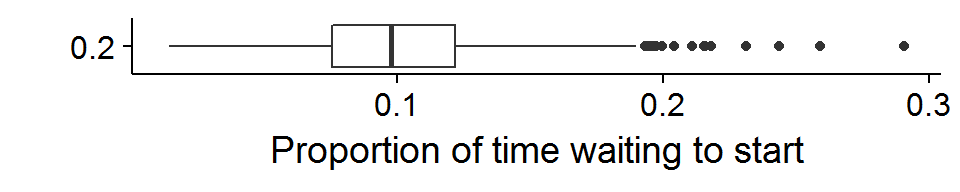

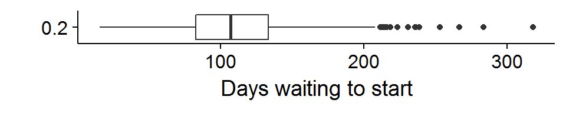

For delta2, the proportionate reduction in accrual during the warm-up period, a beta(14, 21) corresponds to an expectation that the reductiton during warm-up will be about 40% of the regular accrual rate on average. The total weight assigned to this prior (35) is weaker and corresponds to S=0.1.

```
##        S2          delta2
##  Min.   :0.1   Min.   :0.1684
##  1st Qu.:0.1   1st Qu.:0.3467
##  Median :0.1   Median :0.3981
##  Mean   :0.1   Mean   :0.4030
##  3rd Qu.:0.1   3rd Qu.:0.4588
##  Max.   :0.1   Max.   :0.6535
```

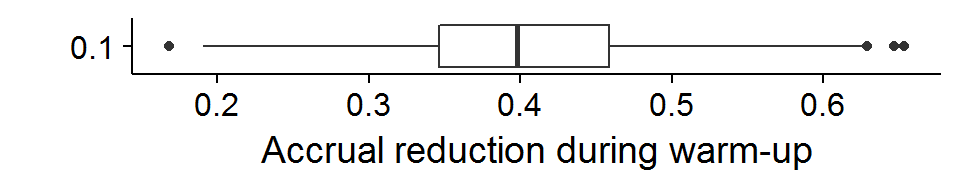

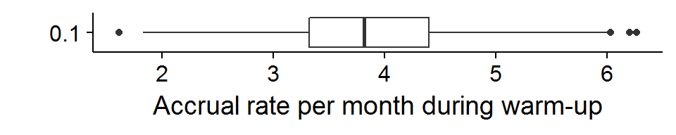

For delta3, the proportion of the total planned time that you spend in the warm-up period, a beta(11.9, 58.1) corresponds to an expectation that 17% of the time your trial will be stuck in the warm-up phase. The total weight assigned to this prior (70) corresponds to S=0.2.

```
##        S3          delta3
##  Min.   :0.2   Min.   :0.05897
##  1st Qu.:0.2   1st Qu.:0.13872
##  Median :0.2   Median :0.16641
##  Mean   :0.2   Mean   :0.17073
##  3rd Qu.:0.2   3rd Qu.:0.19999
##  Max.   :0.2   Max.   :0.34052
```

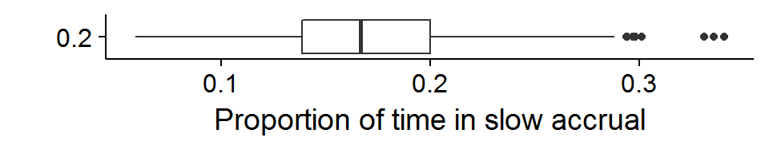

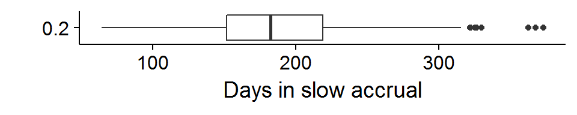

## Fitting a delay model

You should consider exploring how sensitive your estimated total sample size is relative to each of the delay parameters.

The actual trial that I have used so far did not have a formal model for delays, but it is easy enough to modify the data to fit this example. You need to prepend the data with a string of zeros corresponding to the days when the trial was waiting to get started. The day with the first non-zero entry is considered to be the end of the waiting and the beginning of the warm-up period. The end of the warm-up period is unknown, even after the trial is over, but can be estimated by the daily accrual pattern.